# Code for Master Seminar in Econometrics (Part 1)

Subsidizing vocational Training for Disadvantaged Youth in Colombia, Attanasio (2011)

Roman Rakov

05/24

This script covers the application part of the seminar paper. Note that even after using the seed, values slightly differ from the ones reported in the paper due to the nature of the estimators.

## Experimental design

Three months of in-classroom training and three months of on-the-job training to young people between the ages of 18 and 25 in the two lowest socioeconomic strata of the population.

Training institutions were asked to select up to 50 percent more applicants than they had capacity for in each offered class. Then the program randomly filled available slots, the remaining youth were used as a control group.

*Table 1: Data description*

| Variable | Description |
| --- | --- |
| `dwomen` | Indicator for whether the person is a woman |
| `age_lb`, `age_s` | Age |
| `dmarried_lb`, `dmarried_s` | Married status dummy |
| `educ_lb`, `educ_s` | Years of formal education |
| `tenure_04`, `tenure_06` | Tenure on the job |
| `empl_04`, `empl_06` | Employment indicator |
| `pempl_04`, `pempl_06` | Paid employment indicator |
| `salary_04`, `salary_06` | Real salary in Colombian Pesos |
| `profit_04`, `profit_06` | Real net profits in Colombian Pesos |
| `dformal_04`, `dformal_06` | Formal employment indicator |
| `contract_04`, `contract_06` | Written contract indicator |
| `days_04`, `days_06` | Days of work per month in levels |
| `hours_04`, `hours_06` | Hours worked per week |
| `dcontinue` | If the person continues in the sample in the follow-up survey (dummy) |
| `city` | Name of the city where the person lives |
| `codigo_ecap` | Training institution identifier |
| `codigo_curs` | Identifier for the course in which the person registered |
| `p_selecap` | Administrative data: probability of being offered training at a given institution |
| `formalsal_06` | Real salary earned in the formal sector |
| `informalsal_06` | Real salary earned in the informal sector |

**Attrition**

The attrition rate between the baseline and endline surveys is 19.5%. For women, attrition is independent of treatment status and baseline characteristics. For men, treated individuals are 0.07 more likely to remain in the sample. Positive selection occurs if less motivated individuals attrite, negative selection happens if those with better job prospects attrite, making them harder to locate. This potential bias requires careful interpretation for men.

We keep only the observations observed in both periods:

```r
# Keep only rows where 'dcontinue' column is non-zero
df <- df[df$dcontinue != 0, ]
```

**Representative sample**

To compare the sample to the target population, the authors used 2005 National Household Survey (NHS) data. The general population performs better in some areas and worse in others than the sample at hand. Overall, it is unclear whether there is negative or positive selection into the program.

**Covariate balance**

If the randomization was successful, the baseline characteristics of control and treatment groups should not be significantly different, at least **within courses**. They could, however, differ between training institutions and courses because applicants were able to sort by training institution or courses on the basis of tastes, ability, etc..

Overall, the two samples are balanced: the randomization worked well. The F-statistic for women is 1.54 and 2.61 for men. We marginally reject that the baseline characteristics of treated and control men are the same. The baseline imbalance for men points to a slight positive selection bias.

**Outcomes of interest**

Authors consider multiple dependent variables:

1. Labor supply
   - Employment `empl_06` - *binary*
   - Paid employment `pempl_06` - *binary*
   - Days a month `days_06` - *numeric*
   - Hours a week `hours_06` - *numeric*
   - Tenure `tenure_06` - *numeric, missing values*
2. Earnings
   - Wage and salary earnings `salary_06` - *numeric*
   - Self-employment earnings `profit_06` - *numeric*
3. Formal Employment and Earnings
   - Real salary earned in the formal sector `formalsal_06` - *numeric*
   - Real salary earned in the informal sector `informalsal_06` - *numeric*
   - Formal employment indicator `dformal_06` - *binary*
   - Written contract indicator `contract_06` - *binary*

For binary variables (*i.e. the employment indicator* `empl_06`) a conditional logit have been estimated.

In the following, I estimate conditional average treatment effects (CATE) **only with respect to continuous variables**, which is conceptually feasible with `Demean + AIPW` estimation scheme.

## Course Selection and Fixed Effects

### Identification

The treatment effect will be identified in two steps. First, I examine within-course treatment effect, and then move to the program-wide treatment effect.

**(1) Course level treatment effect:**

Since treatment $W$ was randomized at a course level, $E[W | Y(1), Y(0), X] = E(W)$: treatment is independent of potential outcomes and pre-treatment variables $X$. Which also implies mean independence:

$$\begin{align*} E[Y(0) \mid W=0] &= E[Y(0) \mid W=1] = E[Y(0)] \\
E[Y(1) \mid W=0] &= E[Y(1) \mid W=1] = E[Y(1)] \end{align*}$$

By virtue of random assignment, the average treatment effect within a course $C$ can be identified as:

$$\tau_{C} = E[Y(1) - Y(0) \mid C] = E[Y \mid C,W = 1] - E[Y \mid C,W = 0]
= \overline{Y}_{1c} - \overline{Y}_{0c}$$

**(2) Program treatment effect:**

Applicants were able to select themselves into a specific course/training institution. For this reason, the authors use site-by-course fixed effects to eliminate unobserved heterogeneity within each unit that is constant over time.

The overall treatment effect is then a weighted average of the effects across multiple courses, based on the within groups estimator, which gives **variance-weighted** estimates, i.e.,

$$\hat{\tau} = \frac{\sum_{c} P_{c}(1 - P_{c})(\overline{Y}_{1c} -
\overline{Y}_{0c})}{\sum_{c} P_{c}(1 - P_{c})} = \frac{\sum_{c} P_{c}(1
- P_{c})\tau_c}{\sum_{c} P_{c}(1 - P_{c})}$$

where $P_c$ is the share of treated in the sample for a training course $C$; $\overline{Y}_{1c}$ is the average outcome (e.g., wages, employment) for those offered training in course $C$; and $\overline{Y}_{0c}$ is the average outcome for those denied training in course $C$ (Attanasio, 2011).

The sum is taken over all courses, and $\tau$ is the weighted average of the program effects. If $P_c$ is the same across all clusters, then this becomes the simple difference of means between all treated and all control individuals (simple difference in means would serve as an unbiased estimator of the program effect).

It is also straightforward to control for observable pretreatment characteristics:

$$Y_{ij} = \alpha_j + \tau W_i + \rho X_i + \varepsilon_{ij}$$

where $Y_{ij}$ is an outcome for person $i$ in site and course $j$; $\alpha_j$ are site-by-course fixed effects; and $\varepsilon_{ij}$ is a random error term. $X_i$ are pretreatment characteristics.

### Literature background

An established result is that when allowing treatment effects to differ among the groups on which the fixed effects are based, the FE and ATE often differ to a statistically and economically significant extent (Gibbons, 2018).

Fixed effects regressions average the group-specific slopes proportional to both the sample frequency of the group and the conditional variance of treatment, an average that generally does not coincide with the average treatment effect.

In general, the FE is a biased and inconsistent estimator of the ATE:

$$\hat{b}^{FE} \underset{n \rightarrow
\infty}{\stackrel{p}{\longrightarrow}} \beta^{ATE}+\sum_g \pi_g
\beta_g\left[\frac{\operatorname{Var}\left(\widetilde{W}_j \mid
g(j)=g\right)}{\operatorname{Var}\left(\widetilde{W}_j\right)}-1\right]$$

where $π_g$ is population frequency of group g, $\beta_g$ is a group-specific ATE.

Hence, if the variance of the demeaned treatment $\widetilde{W}_j$ conditional on the group varies across groups and treatment effects also vary across groups, then the FE is a biased and inconsistent estimator for the ATE.

FE up-weights groups with high variance in treatment conditional upon other covariates and down-weights groups with low variance in treatment. This is an efficient approach if the treatment effect is the same for all groups, but leads to biased and inconsistent estimates of the ATE when the treatment effect varies across groups.

An example where FE would give unbiased results is a regression using data from a perfectly randomized experiment where treatment has the same variance across groups.

### Constructing unit variable

Create a unit variable to be used for fixed effects:

```r
# Delete observations with missing course identifiers
df <- df[!is.na(df$codigo_curs), ] # only 1 identifier missing

# Create a unique identifier
df$coursefixe <- paste(df$city, df$codigo_ecap, df$codigo_curs, sep = "_")
df$coursefixe <- factor(df$coursefixe)

# Average unit size
temp_df <- df %>% group_by(coursefixe) %>% summarise(count = n())

print(paste("Total number of units:", length(levels(df$coursefixe))))
```

```
[1] "Total number of units: 439"
```

```r
print(paste("Average unit size:", mean(temp_df$count)))
```

```
[1] "Average unit size: 7.37357630979499"
```

```r
# Binarize the 'select' column and compute averages by 'codigo_ecap'
temp_df <- df |>
  mutate(select_binary = ifelse(select == "selected", 1, 0)) |>
  group_by(coursefixe) |>
  summarise(
    average_select = mean(select_binary),
    p_selecap = mean(p_selecap),
    female_share = mean(dwomen))
```

We access the composition of treated and non-treated person across the courses by using factual proportions of people assigned to treatment and control

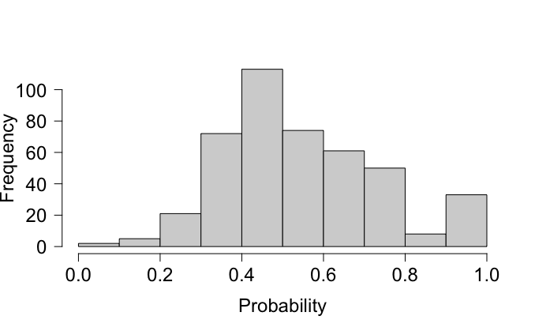

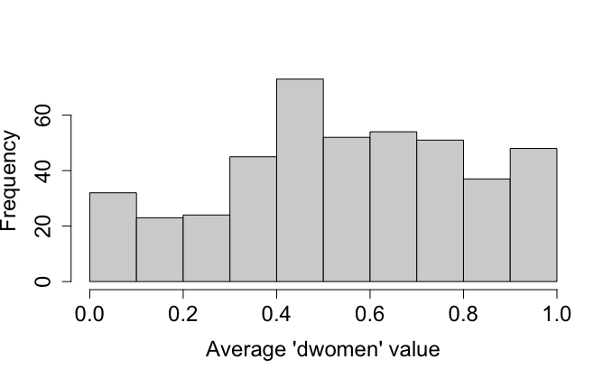

This could potentially bias the effect heterogeneity between men and women reported in the paper.

### Two identical ways to run unit fixed effects

To demonstrate the effect of selection into the courses, I estimate both pooled and fixed effects regressions. Throughout the paper, estimated parameters are analysed separately for men and women. Here I follow this division:

```r
# Subset male participants
male_subset <- subset(df, dwomen == 0)

# Fixed effects model
fe_model <- plm(salary_06 ~ select, data = male_subset, index = c("coursefixe"), model = "within")
# Pooled OLS model
simple_model <- lm(salary_06 ~ select, data = male_subset)

stargazer(fe_model, simple_model, type = "text", title = 'Fixed effects + Pooled OLS, male only, no controls')
```

```
Fixed effects + Pooled OLS, male only, no controls
=================================================================
                                 Dependent variable:
                    ---------------------------------------------
                                      salary_06
                           panel                   OLS
                           linear
                            (1)                    (2)
-----------------------------------------------------------------
selectselected           15,466.390           37,123.670***
                        (12,819.090)           (11,449.920)

Constant                                      265,291.700***
                                               (8,436.619)

-----------------------------------------------------------------
Observations               1,468                  1,468
R2                         0.001                  0.007
Adjusted R2                -0.363                 0.006
Residual Std. Error                      218,539.400 (df = 1466)
F Statistic         1.456 (df = 1; 1075) 10.512*** (df = 1; 1466)
=================================================================
Note:                                 *p<0.1; **p<0.05; ***p<0.01
```

Results are identical to the paper. For wage, the difference between pooled and fixed effects regressions is drastic, but it is less pronounced for other outcomes. Authors note that using fixed effects “*does not make much difference for the results we obtain*”.

There are several ways of obtaining the same fixed effect estimates. Starting with the unobserved effects model:

$$Y_{ij} = \alpha_j + \tau W_i + \rho X_i + \varepsilon_{ij}$$

where $\alpha_j$ is the unit-specific fixed effect (a constant that captures the effect of all time-invariant characteristics specific to unit $j$). OLS estimation with fixed effects yields

$$\big(\widehat{\tau},\widehat{\rho}, \widehat{\alpha}_1, \dots,
\widehat{\alpha}_N) = \underset{\tau, \rho, \alpha_1 \dots
\alpha_N}{\arg\min} \sum_{j=1}^N\sum_{i=1}^T (Y_{ij} -\alpha_j - \tau
W_i - \rho X_{i})^2$$

which amounts to including $N$ individual dummies in regression.

In fact, running a regression with the **coursewise-demeaned** variables $\ddot{Y}_{ij}\equiv Y_{ij} - \overline{Y}_j$ and $\ddot{D}_{ij} \equiv D_{ij} - \overline{D}_j$ (where $D$ includes both $X$ and $W$) is numerically equivalent to a regression of $Y_{ij}$ on $D_{ij}$ and unit-specific dummy variables.

$$\begin{gathered} \widehat{\tau} = \bigg( \sum_{j=1}^N \sum_{i=1}^T
(D_{ij} - \overline{D}_j)'(D_{ij} - \overline{D}_j) \bigg)^{-1}
\bigg( \sum_{j=1}^N \sum_{i=1}^T (D_{ij} - \overline{D}_j)'(Y_{ij} -
\overline{Y}_j)\bigg) \\ \widehat{\tau} = \bigg(\sum_{j=1}^N
\sum_{i=1}^T \ddot{D}_{ij}'\ddot{D}_{ij} \bigg)^{-1} \bigg(
\sum_{j=1}^N \sum_{i=1}^T \ddot{D}_{ij}' \ddot{Y}_{ij}
\bigg)\end{gathered}$$

with the coursewise-demeaned variables $\ddot{D}_{ij} \equiv D_{ij}-\overline{D}_j,\ddot{Y}_{ij} \equiv Y_{ij} - \overline{Y}_j$.

To verify that both specifications are identical, I run two regressions:

1. Pre-implemented in R `plm` fixed effects regression and
2. Course-wise demeaned data and simple `lm` OLS afterwards

```r
# Compute the mean of the outcome and the treatment variable per group
male_demeaned <- male_subset %>%
  group_by(coursefixe) %>%
  mutate(select = ifelse(select == "control", 0, 1),
         salary_06_demeaned = salary_06 - mean(salary_06),
         select_demeaned = select - mean(select)) %>%
  ungroup()

fe_manual <- lm(salary_06_demeaned ~ select_demeaned, data = male_demeaned)
fe_model  <- plm(salary_06 ~ select, data = male_subset, index = c("coursefixe"), model = "within")

summary_fe_model <- summary(fe_model)
stargazer(fe_model,fe_manual, type = "text",title = 'Fixed effects + manual demeaning, male only, no controls')
```

```
Fixed effects + manual demeaning, male only, no controls
================================================================
                                Dependent variable:
                    --------------------------------------------
                         salary_06         salary_06_demeaned
                           panel                   OLS
                           linear
                            (1)                    (2)
----------------------------------------------------------------
selectselected           15,466.390
                        (12,819.090)

select_demeaned                                15,466.390
                                              (10,977.280)

Constant                                         -0.000
                                               (4,716.103)

----------------------------------------------------------------
Observations               1,468                  1,468
R2                         0.001                  0.001
Adjusted R2                -0.363                 0.001
Residual Std. Error                      180,695.100 (df = 1466)
F Statistic         1.456 (df = 1; 1075)  1.985 (df = 1; 1466)
================================================================
Note:                                *p<0.1; **p<0.05; ***p<0.01
```

Point estimates are identical, while standard errors for the demeaned model are misleading: they do not account for the degrees of freedom used for demeaning.

Including pretreatment characteristics increases the precision of the estimates and may help control for any remaining baseline imbalances:

```r
fe_cov <- plm(salary_06 ~ select + dwomen + age_lb + dmarried_lb + educ_lb + empl_04 + pempl_04 + salary_04 + profit_04 + dformal_04 + contract_04 + days_04 + hours_04, data = male_subset, index = c("coursefixe"), model = "within")

summary_fe_cov <- summary(fe_cov)
```

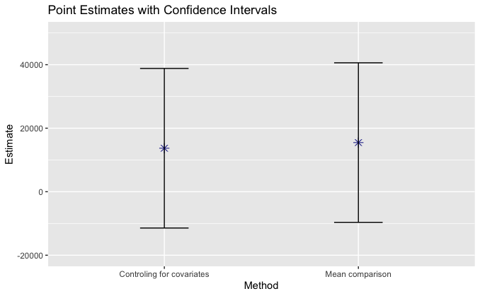

The results are as expected in a proper randomized trial: slightly lower estimates after controlling for covariates (though not more precise).

## CATE estimation using the Doubly Robust scores

**Identification under heterogeneous treatment effects**

The goal is to slightly extend the author’s analysis by using modern techniques that estimate heterogeneous treatment effects non-parametrically.

We consider the standard set of assumptions to hold in this context (e.g., Imbens and Rubin, 2015):

1. **Unconfoundedness:** $Y_i(w) \perp W_i \mid X_i = x, \forall w \in W$ and $x \in X$.
2. **Common Support:** $0 < P[W_i = w \mid X_i = x] \equiv e_w(x), \forall w \in W$ and $x \in X$.
3. **Stable Unit Treatment Value Assumption (SUTVA):** $Y_i = Y_i(W_i)$.

The unconfoundedness assumption requires that $X_i$ contains all confounding variables that jointly affect program assignment and the outcome. Common support states that it must be possible to observe each individual in all programs. SUTVA rules out interference.

In the present context,

1. **Unconfoundedness** is assumed to hold due to coursewise demeaning of the data, eliminating applicants’ self-selection bias.
2. **Common Support** is assumed to hold under the proper randomization design, which is true in our context.
3. **SUTVA** is rather hard to defend in light of the multiple effective treatments present in the study (each course essentially acts as an effective treatment, producing variation in potential outcomes). The violation of SUTVA will be discussed at the end of the paper.

Then, we can use the doubly robust (DR) estimator of Robins and Rotnitzky (1995):

$$\widetilde{Y}_{ATE} =
\underbrace{\hat{m}(1,\ddot{X}) - \hat{m}(0,\ddot{X})}_{\text{outcome
predictions}} + \underbrace{\frac{W (\ddot{Y} -
\hat{m}(1,\ddot{X}))}{\hat{e}(\ddot{X})} - \frac{(1-W) (\ddot{Y} -
\hat{m}(0,\ddot{X}))}{1-\hat{e}(\ddot{X})}}_{\text{weighted
residuals}}$$

With transformed variables $\ddot{Y}, \ddot{X}$. Treatment indicator $W$ remains untouched.

Course-wise demeaning the data:

```r
# Identify levels with only one observation
counts <- table(df$coursefixe)
single_obs_levels <- names(counts[counts == 1])

# Remove observations corresponding to single observation levels
df_filtered <- df[!(df$coursefixe %in% single_obs_levels), ]

# Filter out rows where "select" takes all zeros or all ones within each group of "coursefixe"
df_filtered <- df_filtered |>
  group_by(coursefixe) |>
  filter(!(all(select == "control") | all(select == "selected"))) |>
  mutate(select = ifelse(select == "control", 0, 1)) |>
  ungroup()
```

We also have to enforce the common support for treatment (no fully-treated or fully-control groups):

```r
variable_names <- c("dwomen","age_lb", "dmarried_lb", "educ_lb", "empl_04", "pempl_04", "salary_04", "dformal_04", "contract_04", "days_04", "hours_04", "profit_04", "coursefixe")

X <- df_filtered[variable_names] # df or df_filtered?
X <- X %>%
  group_by(coursefixe) %>%
  mutate_at(vars(-group_cols()), ~. - mean(.)) %>%
  ungroup() %>%
  select(-coursefixe)

W <- df_filtered$select # df or df_filtered?

demean <- function(df, variable_name) {
  df %>%
    select({{ variable_name }}, coursefixe) %>%
    group_by(coursefixe) %>%
    mutate({{ variable_name }} := {{ variable_name }} - mean({{ variable_name }})) %>%
    ungroup() %>%
    pull({{ variable_name }})}

Y_salary <- demean(df_filtered, salary_06)
Y_days   <- demean(df_filtered, days_06)
Y_hours  <- demean(df_filtered, hours_06)
Y_profit <- demean(df_filtered, profit_06)
Y_form   <- demean(df_filtered, formalsal_06)
Y_inform <- demean(df_filtered, informalsal_06)

Y <- cbind(Y_salary, Y_days, Y_hours, Y_profit, Y_form, Y_inform)
Y <- as.data.frame(Y)
```

### Heterogeneous effects

The estimation is based on the `causalDML` R-package proposed by Knaus (2022):

```r
cDML       <- list()
outcomes_Y <- c("salary_06","days_06", "hours_06", "profit_06", "formalsal_06", "informalsal_06")

# Create the ML method to be used for nuisance parameter prediction
forest = create_method("forest_grf",args=list(tune.parameters = "all",seed=123))

# Run the main function that outputs nuisance parameters, APO and ATE
for (i in 1:ncol(Y)) {
  cDML[[i]] <- DML_aipw(Y[,i], W, X, ml_w = list(forest), ml_y = list(forest), cv = 3)}
```

Importantly, `na` obervations of `tenure` are deleted

```r
# And one for the tenure_06
Y_tenure <- df_filtered %>%
    filter(!is.na(tenure_06)) %>%
    select(tenure_06, coursefixe) %>%
    group_by(coursefixe) %>%
    mutate(tenure_06 := tenure_06 - mean(tenure_06)) %>%
    ungroup() %>%
    pull(tenure_06)

# Select elements from X, Y, and W corresponding to non-NA elements in tenure_06
X_ten <- X[which(!is.na(df_filtered$tenure_06)), ]
# Y_tenure <- Y_tenure[which(!is.na(df_filtered$tenure_06))]
W_ten <- W[which(!is.na(df_filtered$tenure_06))]

cDML[[7]] <- DML_aipw(Y_tenure, W_ten, X_ten, ml_w = list(forest), ml_y = list(forest), cv = 3)
```

**Subgroup effect**

The analysis and policy recommendation in Attanasio (2011) are based on gender subgroup analysis, which is a rather standard setup for empirical work when possible effect heterogeneity is considered. With the estimated pseudo-outcome $\widetilde{Y}_{ATE}$, this boils down to running an OLS regression with the `dwomen` as a single regressor.

```r
temp_df = data.frame(y = cDML[[1]]$ATE$delta)
temp_df = cbind(temp_df,X)
names(temp_df)[1] <- "y"

GATE_ols = summary(lm_robust(as.formula("y ~ dwomen"),data = temp_df))
GATE_ols
```

```
Call:
lm_robust(formula = as.formula("y ~ dwomen"), data = temp_df)

Standard error type:  HC2

Coefficients:
            Estimate Std. Error t value  Pr(>|t|) CI Lower CI Upper   DF
(Intercept)    26770       6658   4.021 5.945e-05    13715    39825 3117
dwomen         20627      16204   1.273 2.031e-01   -11145    52400 3117

Multiple R-squared:  0.0005533 ,    Adjusted R-squared:  0.0002327
F-statistic:  1.62 on 1 and 3117 DF,  p-value: 0.2031
```

```r
coefficients_table <- GATE_ols$coefficients
print(coefficients_table)
```

```
            Estimate Std. Error  t value     Pr(>|t|)  CI Lower CI Upper   DF
(Intercept) 26769.73   6658.272 4.020522 5.944518e-05  13714.69 39824.77 3117
dwomen      20627.06  16204.489 1.272923 2.031403e-01 -11145.49 52399.62 3117
```

The interpretation is kept in the report.

Here is the possible workaround for the ‘dummy’ coefficient interpretation issue:

```r
# Compute mean for values <= 0
mean_dwomen_le_0 <- mean(X$dwomen[X$dwomen < 0], na.rm = TRUE)

# Compute mean for values > 0
mean_dwomen_gt_0 <- mean(X$dwomen[X$dwomen > 0], na.rm = TRUE)

# Print the results
print(paste("Mean for values < 0:", mean_dwomen_le_0))
```

```
[1] "Mean for values < 0: -0.451180941164851"
```

```r
print(paste("Mean for values > 0:", mean_dwomen_gt_0))
```

```
[1] "Mean for values > 0: 0.382810859978095"
```

```r
print(paste("Coefficient after the adjustmewnt (close to the truth):", coefficients_table[1, "Estimate"] + mean(X$dwomen[X$dwomen>0])*coefficients_table[2, "Estimate"]))
```

```
[1] "Coefficient after the adjustmewnt (close to the truth): 34665.994568847"
```

**Best linear prediction for** **the** **GATEs**

We model the effect heterogeneity using all available main effects at our disposal. In standard OLS this would mean to include a lot of interaction effects while completely relying on correct specification of $Y$.

Using $\widetilde{Y}_{ATE}$ allows us to be completely agnostic about the outcome model and to receive a nice summary of the underlying effect heterogeneity:

```r
options(scipen = 999) # suppress scientific notation

for (i in 1:6) {
  cat(paste("\n\n",outcomes_Y[i]),":\n")
  temp_ols <- lm_robust(cDML[[i]]$ATE$delta ~ ., data = X)
  print(summary(temp_ols))}
```

```
 salary_06 :

Call:
lm_robust(formula = cDML[[i]]$ATE$delta ~ ., data = X)

Standard error type:  HC2

Coefficients:
                Estimate Std. Error  t value  Pr(>|t|)    CI Lower    CI Upper   DF
(Intercept)  27500.61996  6719.9579  4.09238 0.0000438  14324.5243  40676.7156 3055
dwomen       20311.92911 17051.8768  1.19118 0.2336738 -13122.3817  53746.2399 3055
age_lb       -2200.08875  3771.6954 -0.58332 0.5597239  -9595.4059   5195.2284 3055
dmarried_lb   4852.82924 19331.1710  0.25104 0.8018028 -33050.5866  42756.2451 3055
educ_lb       7917.46562  4719.1450  1.67773 0.0935015  -1335.5545  17170.4858 3055
empl_04      53100.40245 46463.7023  1.14284 0.2531961 -38002.8747 144203.6796 3055
pempl_04    -16232.57128 39485.7624 -0.41110 0.6810285 -93653.9169  61188.7744 3055
salary_04       -0.05574     0.1086 -0.51328 0.6077936     -0.2687      0.1572 3055
dformal_04   -3368.11899 36913.7724 -0.09124 0.9273056 -75746.4590  69010.2210 3055
contract_04  27842.48434 38956.5798  0.71471 0.4748456 -48541.2715 104226.2402 3055
days_04       -685.22067  1983.9643 -0.34538 0.7298328  -4575.2604   3204.8190 3055
hours_04      -541.39827   638.8671 -0.84743 0.3968191  -1794.0510    711.2544 3055
profit_04       -0.07141     0.1462 -0.48842 0.6252895     -0.3581      0.2153 3055

Multiple R-squared:  0.003316 , Adjusted R-squared:  -0.0005991
F-statistic: 0.8636 on 12 and 3055 DF,  p-value: 0.5842


 days_06 :

Call:
lm_robust(formula = cDML[[i]]$ATE$delta ~ ., data = X)

Standard error type:  HC2

Coefficients:
                 Estimate  Std. Error   t value Pr(>|t|)    CI Lower    CI Upper   DF
(Intercept)  0.4997477427 0.376984050  1.325647 0.185056 -0.23942027  1.23891575 3055
dwomen       1.0679789568 0.934401583  1.142955 0.253147 -0.76414036  2.90009827 3055
age_lb       0.0693954046 0.209066590  0.331930 0.739965 -0.34052999  0.47932080 3055
dmarried_lb  0.6436379734 1.081859232  0.594937 0.551930 -1.47760757  2.76488352 3055
```

[output cut: 105 more lines]

```
dwomen       12407.936011 14916.5184  0.83183   0.4056 -16839.4904  41655.3624 3055
age_lb        3357.518155  3283.6543  1.02249   0.3066  -3080.8769   9795.9132 3055
dmarried_lb -19482.307141 17244.4188 -1.12977   0.2587 -53294.1428  14329.5286 3055
educ_lb       2416.901597  4122.5168  0.58627   0.5577  -5666.2853  10500.0885 3055
empl_04      61530.331121 40875.2332  1.50532   0.1323 -18615.4066 141676.0689 3055
pempl_04    -11745.427017 37390.2340 -0.31413   0.7534 -85057.9846  61567.1305 3055
salary_04        0.058867     0.1126  0.52266   0.6013     -0.1620      0.2797 3055
dformal_04   25294.665792 30336.7559  0.83380   0.4045 -34187.8494  84777.1810 3055
contract_04  19913.119372 32508.3497  0.61255   0.5402 -43827.3284  83653.5671 3055
days_04      -2066.457629  1854.4604 -1.11432   0.2652  -5702.5739   1569.6586 3055
hours_04      -444.909520   580.8488 -0.76596   0.4438  -1583.8036    693.9845 3055
profit_04       -0.005155     0.1127 -0.04574   0.9635     -0.2261      0.2158 3055

Multiple R-squared:  0.003641 , Adjusted R-squared:  -0.0002723
F-statistic: 0.9432 on 12 and 3055 DF,  p-value: 0.502
```

And separately for the `tenure`:

```r
temp_df = data.frame(y = cDML[[7]]$ATE$delta)
temp_df = cbind(temp_df,X_ten)
names(temp_df)[1] <- "y"

GATE_ols = summary(lm_robust(as.formula("y ~ ."),data = temp_df))
GATE_ols
```

```
Call:
lm_robust(formula = as.formula("y ~ ."), data = temp_df)

Standard error type:  HC2

Coefficients:
                Estimate  Std. Error  t value   Pr(>|t|)    CI Lower    CI Upper   DF
(Intercept) -1.894076951 0.454346192 -4.16880 0.00003148 -2.78493381 -1.00322009 3040
dwomen       0.215347127 1.145985294  0.18791 0.85095630 -2.03163740  2.46233165 3040
age_lb      -0.501058107 0.303373162 -1.65162 0.09871470 -1.09589541  0.09377919 3040
dmarried_lb  2.453064602 1.323978903  1.85280 0.06400826 -0.14291994  5.04904914 3040
educ_lb     -0.194759859 0.388931307 -0.50076 0.61657879 -0.95735483  0.56783512 3040
empl_04     -1.363718062 3.994174011 -0.34143 0.73280590 -9.19527336  6.46783723 3040
pempl_04     0.232219215 3.701175447  0.06274 0.94997606 -7.02484071  7.48927914 3040
salary_04    0.000009831 0.000005871  1.67465 0.09410624 -0.00000168  0.00002134 3040
dformal_04  -0.312941384 2.661428558 -0.11758 0.90640506 -5.53132317  4.90544040 3040
contract_04  0.049716920 2.892795774  0.01719 0.98628899 -5.62231690  5.72175074 3040
days_04     -0.097074283 0.155422765 -0.62458 0.53229222 -0.40181864  0.20767007 3040
hours_04     0.011098841 0.052566706  0.21114 0.83279357 -0.09197105  0.11416873 3040
profit_04   -0.000007616 0.000016462 -0.46264 0.64365391 -0.00003989  0.00002466 3040

Multiple R-squared:  0.006624 , Adjusted R-squared:  0.002703
F-statistic: 0.9558 on 12 and 3040 DF,  p-value: 0.4894
```

```r
# Assuming GATE_ols is your summary object
coefficients_table <- GATE_ols$coefficients
```

### Nonparametric GATEs for continuous heterogeneity variables

While subgroup analyses are standard in program evaluations, the estimation of non-parametric GATEs using kernel or series regression is rarely pursued.

I estimate such GATEs along four continuous variables:

Considering no visible treatment effect heterogeneity (measured by the $F$ statistics in the BLP), I will abstain from interpreting this graphs. Multiple hypothesis testing is clearly an issue. Plots are shows to display the hypothetical merits of Kernel regression for GATE estimation.

Importantly: population mean is re-added to the axis:

```r
## for plotting
# pdf("sp_salary_age_plot.pdf", width = 8, height = 6)  # Dimensions in inches
# plot(sp_salary_age,z_label="Age prior to training")
# dev.off()

Xed <- X[,"educ_lb"]
Xed[,"educ_lb"][is.na(X[,"educ_lb"])] <- 0

## Series regression GATEs
sp_salary_educ = spline_cate(cDML[[1]]$ATE$delta,Xed)
```

[output not shown]

[output cut: 47 more lines]

[output not shown]

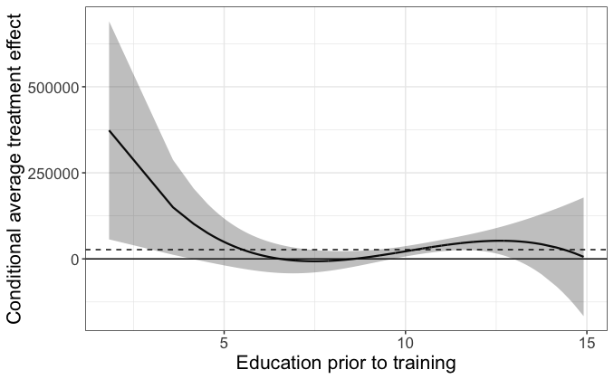

```r
sp_salary_educ[["z"]] = sp_salary_educ[["z"]] + mean(df_filtered$educ_lb, na.rm = TRUE)
print(plot(sp_salary_educ,z_label="Education prior to training"))
```

```r
## Second one
sp_salary_age = spline_cate(cDML[[1]]$ATE$delta,X[,"age_lb"])
```

[output not shown]

[output cut: 47 more lines]

[output not shown]

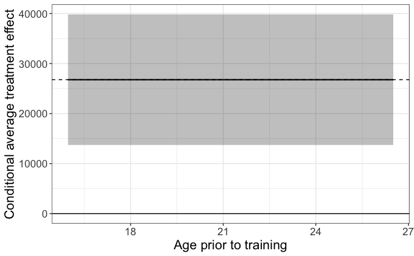

```r
sp_salary_age[["z"]] = sp_salary_age[["z"]] + mean(df_filtered$age_lb, na.rm = TRUE)
print(plot(sp_salary_age,z_label="Age prior to training"))
```

```r
## Third pne
sp_salary_hours = spline_cate(cDML[[1]]$ATE$delta,X[,"hours_04"])
```

[output not shown]

[output cut: 47 more lines]

[output not shown]

[figure not shown]

```r
sp_salary_hours[["z"]] = sp_salary_hours[["z"]] + mean(df_filtered$hours_04, na.rm = TRUE)
print(plot(sp_salary_hours,z_label="Hours of work per day prior to training"))
```

```r
## Fourth one
sp_days_days = spline_cate(cDML[[2]]$ATE$delta,X[,"days_04"])
```

[output not shown]

[output cut: 47 more lines]

[output not shown]

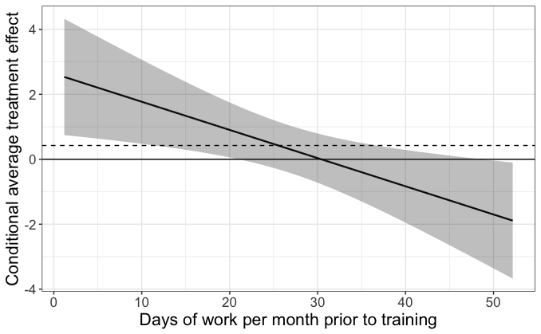

```r
sp_days_days[["z"]] = sp_days_days[["z"]] + mean(df_filtered$hours_04, na.rm = TRUE)
print(plot(sp_days_days,z_label="Days of work per month prior to training"))
```

Kernels are very similar (uncomment to run).

```r
## Kernel regression CATEs
# kr_salary_educ   = kr_cate(cDML[[1]]$ATE$delta,Xed)
# kr_salary_age    = kr_cate(cDML[[1]]$ATE$delta,X[,"age_lb"])
# kr_days_days     = kr_cate(cDML[[2]]$ATE$delta,X[,"days_04"])
# kr_profir_salary = kr_cate(cDML[[4]]$ATE$delta,X[,"salary_04"])

# To change the axis:
# kr_salary_educ[["model"]][["eval"]][["educ_lb"]] = kr_salary_educ[["model"]][["eval"]][["educ_lb"]] + mean(df$educ_lb, na.rm = TRUE)

# Plot Kernel regression CATEs
# print(plot(kr_salary_educ,z_label="Education prior to training"))
# print(plot(kr_salary_age,z_label="Age prior to training"))
# print(plot(kr_days_days,z_label="Days of work per month prior to training"))
# print(plot(kr_profir_salary,z_label="Salary prior to training"))
```

## Policy learning

### Cost-Benefit Analysis

Authors calculate the benefits of the program through salary gains, using monthly gains from fixed effects regression and controlling for pre-treatment covariates: COP$34,668 monthly, about COP$416,000 annually.

**Are these gains permanent?** Two scenarios are considered:

1. Gains are permanent but do not grow.
2. Gains depreciate 10 percent annually.

Assuming 40 more working years (average age 22) and discounting at 5 percent annually, the first scenario yields a gain of US$3,805 for women. With a 10 percent annual depreciation, the gain is US$1,478.25.

The program’s direct cost is US$750 per person. It caused a loss of 1.43 months of tenure, valued at US$62. Thus, net lifecycle gains for women are US$2,993 under permanent effects and US$666 with depreciation, showing the program’s effectiveness for women. For men, there are no easily measurable gains. The shift to the formal sector offers non-monetary benefits and potentially better job attachment, but data is insufficient to evaluate this.

### Policy tree

The last section is an exercise for the student, without any statistical validity or significance.

The goal is to maximize the value function of treatment assignment policies. This involves comparing various policy rules to identify the one that yields the highest mean APO score. The process accounts for finite samples and estimated nuisance parameters, with the objective of minimizing the difference (regret) between the estimated and true optimal value functions.

**If** the previous section documented substantial heterogeneities in the program effects, we could leverage this heterogeneity for better targeting. We apply the DML-based optimal policy algorithm.

Using the `policy tree` method:

```r
# Set missing values to zero (~50 values in educ)
X_na <- X
X_na[is.na(X_na)] <- 0
# df_na <- df[variable_names]
# df_na[is.na(df_na)] <- 0
```

Trees of depth 1:

```r
# Run policy tree
pt1 = policy_tree(X_na,cDML[[1]]$APO$gamma,depth=1)
pi_hat_pt1 = predict(pt1,newdata=X_na)

label_w <- c("control", "treatment")

pt1[["nodes"]][[1]][["split_value"]] = pt1[["nodes"]][[1]][["split_value"]] + mean(df_filtered$educ_lb, na.rm = TRUE)

## for plotting
# pdf("tree_1", width = 8, height = 6)  # Dimensions in inches
plot(pt1,label_w)
```

[interactive chart not shown]

```r
# dev.off()
```

Trees of depth 2:

```r
# Run policy tree
pt1 = policy_tree(X_na,cDML[[1]]$APO$gamma,depth=2)
pi_hat_pt1 = predict(pt1,newdata=X_na)

label_w <- c("control", "treatment")
# pt1[["nodes"]][[1]][["split_value"]] = pt1[["nodes"]][[1]][["split_value"]] + mean(df_filtered$educ_lb, na.rm = TRUE)

pt1[["nodes"]][[1]][["split_value"]] = pt1[["nodes"]][[1]][["split_value"]] + mean(df_filtered$dwomen, na.rm = TRUE)
pt1[["nodes"]][[2]][["split_value"]] = pt1[["nodes"]][[1]][["split_value"]] + mean(df_filtered$age_lb, na.rm = TRUE)
pt1[["nodes"]][[3]][["split_value"]] = pt1[["nodes"]][[1]][["split_value"]] + mean(df_filtered$dwomen, na.rm = TRUE)


## for plotting
# pdf("tree_1", width = 8, height = 6)  # Dimensions in inches
plot(pt1,label_w)
```

[interactive chart not shown]

```r
# dev.off()
```

Action 1 means no treatment, action 2 means treatment. Interpretation here is quite problematic, but it follows some common sense: `age_lb` and `dwomen` are the variables with the highest (relative) treatment effect heterogeneity.